# Fivegas Data Processing

# Load data

- fivegas

```r
  data <- readRDS("../r_files/fivegas.RDS")
```

- sample information

```r
  test_info <- readRDS("../r_files/test_info.RDS")
  notes <- readRDS("../r_files/qc.RDS")
```

- sample times

```r
  times_fuel <- readRDS("../r_files/times_fuel.RDS")
  times_bg <- readRDS("../r_files/times_bg.RDS")
  times_test <- readRDS("../r_files/times_test.RDS")
```

# Units

- Convert co2 from percent to ppm (note CO and CH4 are collected as ppm)

```r
  out <- dplyr::mutate(data, co2 = co2 * 10^4)
```

# Convert to longer format

```r
 out <- tidyr::gather(out, "pol", "val", 1:5) %>%
        dplyr::filter(grepl("^co$|^co2$|^ch4$", pol))
```

# Filter times

- full test

```r
  out_full <- filter_times_startup(times_test, out)
```

- background levels

```r
  out_bg <- filter_times_background(times_bg, out)
```

- levels by replicate

```r
  out_rep <- filter_times_rep(times_fuel, out)
```

## Background

- calculate mean backgrounds

```r
  bg <- dplyr::group_by(out_bg, id, type, pol) %>%
        dplyr::summarise(mean = mean(val, na.rm = TRUE)) %>%
        tidyr::spread(type, mean) %>%
        mutate(delta = post - pre,
               bg_ppm = (pre + post) / 2,
               bg_ppm = ifelse(is.na(bg_ppm), pre, bg_ppm),
               bg_ppm = ifelse(is.na(bg_ppm), post, bg_ppm))
```

- append to fivegas data

```r
  out_full <- dplyr::left_join(out_full,
                               dplyr::select(bg, id, pol, bg_ppm),
                               by = c("id", "pol"))
  out_full <- dplyr::left_join(out_full,
                              dplyr::select(test_info, id, fuel_type),
                              by = "id")

  out_rep <- dplyr::left_join(out_rep,
                              dplyr::select(bg, id, pol, bg_ppm),
                              by = c("id", "pol"))
  out_rep <- dplyr::left_join(out_rep,
                              dplyr::select(test_info, id, fuel_type),
                              by = "id")
```

# QC

```r
  notes <- dplyr::filter(notes, grepl("fivegas|all", instrument))

  out_full <- dplyr::left_join(out_full,
                              dplyr::select(notes, id, qc, id_test),
                              by = "id")



  out_rep <- dplyr::left_join(out_rep,
                              dplyr::select(bg, id, pol, bg_ppm),
                              by = c("id", "pol"))

  out_bg <- dplyr::left_join(out_bg,
                             dplyr::select(bg, id, pol, bg_ppm),
                             by = c("id", "pol"))
```

# Save to file

```r
  saveRDS(out_full, file = "../r_files/fivegas_full.RDS")
  saveRDS(out_bg, file = "../r_files/fivegas_background.RDS")
  saveRDS(out_rep, file = "../r_files/fivegas_byrep.RDS")
```

# Summary

Fivegas data was collected during 39 experiments between 2016-10-01 and 2017-02-02. There is no fivegas data for tests: 36, 37, 38, 39, 40, 41, 42, 43.

Tests 36 through 43 are blanks; no fivegas data expected.

All fivegas data is present as expected as of 6/7/17.

The study test notes indicated that the QC status of the available data is:

```r
  single <- filter(out_full,pol=="ch4")
  table(notes$qc)
```

```
##
##   bad  good maybe
##     1    38    12
```

```r
  table(notes$instrument)
```

```
##
##         all    carbonyl temperature
##          51           0           0
```

```r
  print(notes$id_test[which(notes$qc == "bad")])
```

```
## [1] L1
## 47 Levels: B1 B2 B3 B4 B5 B6 B7 B8 BG1 BG2 BG3 BG4 BG5 F1 F2 F3 G1 ... W3
```

```r
  print(notes$notes[which(notes$qc ==  "bad")])
```

```
## [1] " nonstandard test - did not follow protocol. Added leaves/twigs continuously trying to produce a startup. CENSOR THIS TEST FROM FINAL DATASET!"
```

```r
  print(notes$id_test[which(notes$qc == "maybe")])
```

```
##  [1] BG5  F1   F2   G3   K2   L1   N1.1 N3   P1   P2   W1   W1.1
## 47 Levels: B1 B2 B3 B4 B5 B6 B7 B8 BG1 BG2 BG3 BG4 BG5 F1 F2 F3 G1 ... W3
```

```r
  print(notes$notes[which(notes$qc == "maybe")])
```

```
##  [1] "wood tests in hood 2; there were 3 other stoves running in different hoods during this day of testing"
##  [2] "charcoal test in hood 2 starting 10:55; carbonyl started about 30 minutes before test started; charcoal test in hood 2 starting 10:55"
##  [3] " there were 3 other stoves running in different hoods during this day of testing"
##  [4] " there were 3 other stoves running in different hoods during this day of testing"
##  [5] " there were 3 other stoves running in different hoods during this day of testing"
##  [6] "non-standart test, just added leaves and twigs continuosly to try to produce start up characteristics to capture some data for filter"
##  [7] "charcoal test Thing 2"
##  [8] " there were 3 other stoves running in different hoods during this day of testing"
##  [9] "2 matches used to light first bag (put in stove with bag(; 2 matches used to light first set of starter material, both were burned with the bag."
## [10] "piece C: match burned with bag; startup rep C - match was burned with the starter"
## [11] "used different shims, went out at least 6 times each; shim type was different than then rest of the W tests; sets of shims went out regularly and had to be relit many times"
## [12] "went out at 12:35:30--relit with match; burn went out at 12:35:30, was relit using a match"
```

There are no “bad” fivegas data according to study protocol notes - only some “bad” and “maybe” QC that are due to protocol notes that apply across all instruments. According to those notes, test L1 should definitely be excluded, and test W1 should maybe be excluded.

# Plots and Tables

## Summary Tables

*Summary Values Across All Fuel Tests*

| pollutant | mean value (ppm) | value median (ppm) | max value (ppm) | minimum value (ppm) | standard error |
| --- | --- | --- | --- | --- | --- |
| ch4 | 21.96 | 22 | 73 | 11 | 5.28 |
| co | 20.71 | 8 | 537 | 0 | 35.44 |
| co2 | 1122.87 | 780 | 7320 | 480 | 901.31 |

*Summary Values Across All Background Tests*

| pollutant | mean value (ppm) | value median (ppm) | max value (ppm) | minimum value (ppm) | standard error |
| --- | --- | --- | --- | --- | --- |
| ch4 | 16.69 | 20 | 23 | 2 | 6.89 |
| co | 2.65 | 3 | 4 | 1 | 0.81 |
| co2 | 598.95 | 600 | 740 | 480 | 63.64 |

*Summary Values Across Background Measured Before/After Each Test*

| pollutant | mean value (ppm) | value median (ppm) | max value (ppm) | minimum value (ppm) | standard error |
| --- | --- | --- | --- | --- | --- |
| ch4 | 16.69 | 20 | 23 | 2 | 6.89 |
| co | 2.65 | 3 | 4 | 1 | 0.81 |
| co2 | 598.95 | 600 | 740 | 480 | 63.64 |

## Test Plots

### All pollutants

#### by total time

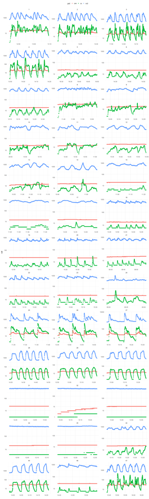

- background

Tests 31-35 are “flat”, which is as expected as these are background tests where no burning occured.

The CH4 looks odd for all tests.

#### by replicates

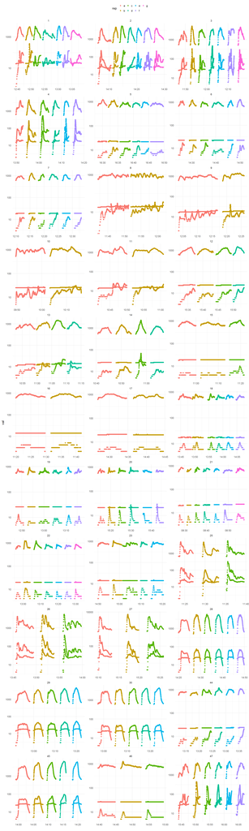

### CH4 only

#### by time total

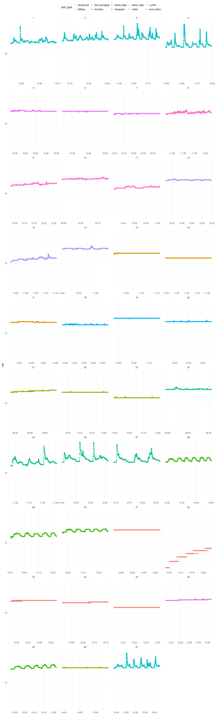

#### by replicates

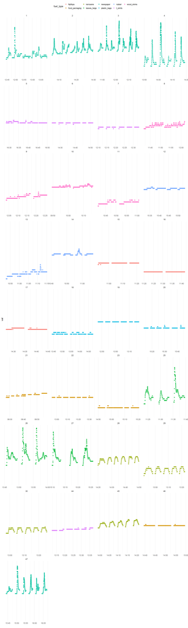

## background times pre/post test

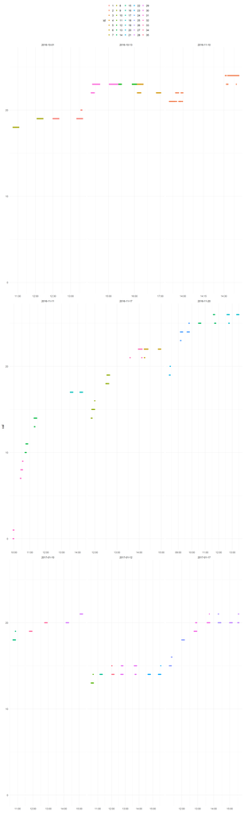

#### by replicates, average background shown.

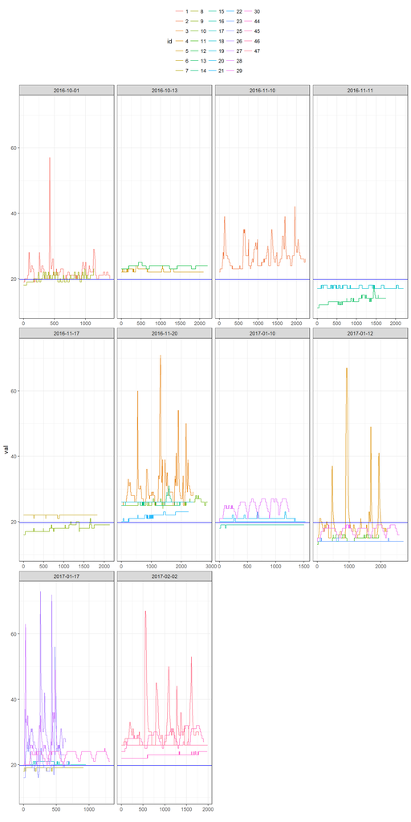

# Data Quality Conclusions (KF on 6/16/17)